# 1. Linear Time-Invariant (LTI) Systems

## 2.3. Convolution for Finite-Length Signals

In the case of finite-length signals of length $N$, convolution is performed using **circular convolution**, which assumes periodic (modulo-$N$) signal boundaries.

The circular convolution of two length-$N$ signals $x[n]$ and $h[n]$ is defined as:

$$ y[n] = x[n] \otimes h[n] = \sum_{m = 0}^{N-1} h\left[(n - m)_N\right] \, x[m] $$

Here, $(n - m)_N$ denotes modular arithmetic (i.e., reduction modulo $N$) to ensure the indices wrap around circularly.

**Interpretation:**

- The impulse response $h[n]$ is first circularly time-reversed.
- It is then circularly shifted by $n$ steps to the right.
- The output $y[n]$ is computed as the inner product of this shifted version of $h$ with the input vector $x$.

Circular convolution naturally arises in systems where periodic boundary conditions are assumed, and it is central to frequency-domain signal processing using the Discrete Fourier Transform (DFT).

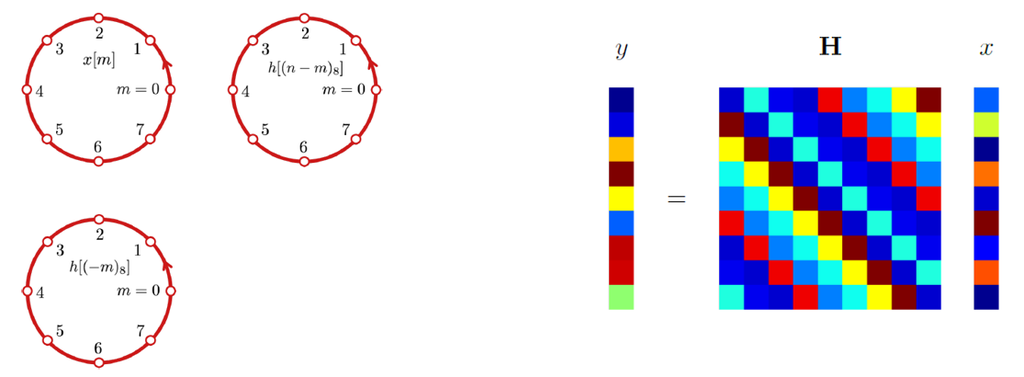

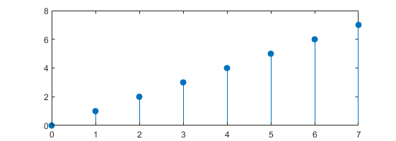

```matlab
%plot -s 560,200

N = 8;
n = 0:N-1;

h = [0 1 2 3 4 5 6 7]';

stem(n,h,'filled');
```

```matlab
%% Create a circulent matrix H based on h

H = zeros(N,N);
for k = 0:N-1
    H(:,k+1) = circshift(h,k);
end
H
```

```
H =

     0     7     6     5     4     3     2     1
     1     0     7     6     5     4     3     2
     2     1     0     7     6     5     4     3
     3     2     1     0     7     6     5     4
     4     3     2     1     0     7     6     5
     5     4     3     2     1     0     7     6
     6     5     4     3     2     1     0     7
     7     6     5     4     3     2     1     0
```

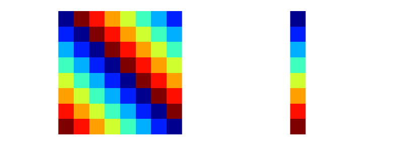

```matlab
%plot -s 800,300

subplot(1,2,1), imagesc(H); colormap('jet'); axis('square'); axis off
subplot(1,2,2), imagesc(h); colormap('jet'); axis equal; axis off
```

```matlab
x = [1,1,0,0,0,0,0,0]';
y1 = H*x
```

```
y1 =

     7
     1
     3
     5
     7
     9
    11
    13
```

```matlab
x = [1,1,0,0,0,0,0,0];
h = [0,1,2,3,4,5,6,7];

y3 = cconv(x,h,8)
```

```
y3 =

    7.0000    1.0000    3.0000    5.0000    7.0000    9.0000   11.0000   13.0000
```

```matlab
x1 = [1,2,2];
x2 = [1,2,3,4];

y = cconv(x1,x2,4)

% 5-point circular convolution
y = cconv(x1,x2,5)

% 6-point circular convolution
y = cconv(x1,x2,6)
```

```
y =

    15    12     9    14


y =

     9     4     9    14    14


y =

     1     4     9    14    14     8
```

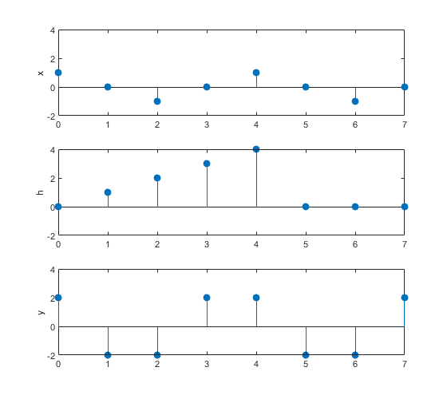

```matlab
%plot -s 560,500

N = 8;
xn = 0:N-1;
x = [1 0 -1 0 1 0 -1 0];
h = [0 1 2 3 4 0 0 0];
y = cconv(x,h,N);

subplot(3,1,1), stem(xn,x,'filled'), ylim([-2 4]), ylabel('x')
subplot(3,1,2), stem(xn,h,'filled'), ylim([-2 4]), ylabel('h')
subplot(3,1,3), stem(xn,y,'filled'), ylim([-2 4]), ylabel('y')
```

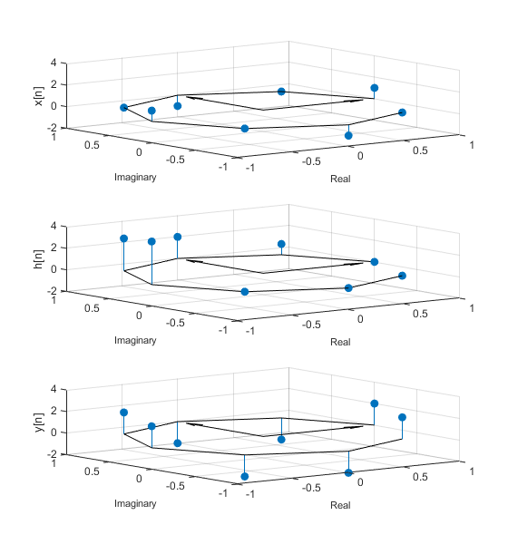

```matlab
%plot -s 560,600

N = 8;
theta2 = (0:1/N:1)*2*pi;
theta = theta2(1:end-1);

re = cos(theta);
im = sin(theta);

subplot(3,1,1),  stem3(re,im,x,'filled');   hold on;
plot(re,im,'k')
quiver(0,0,1,0,'k','maxheadsize',0.5)
quiver(0,0,0,1,'k','maxheadsize',0.5), hold off
xlabel('Real','fontsize',8), ylabel('Imaginary','fontsize',8), zlabel('x[n]')
zlim([-2,4])

subplot(3,1,2),  stem3(re,im,h,'filled');   hold on;
plot(re,im,'k')
quiver(0,0,1,0,'k','maxheadsize',0.5)
quiver(0,0,0,1,'k','maxheadsize',0.5), hold off
xlabel('Real','fontsize',8), ylabel('Imaginary','fontsize',8), zlabel('h[n]')
zlim([-2,4])

subplot(3,1,3),  stem3(re,im,y,'filled');   hold on;
plot(re,im,'k')
quiver(0,0,1,0,'k','maxheadsize',0.5)
quiver(0,0,0,1,'k','maxheadsize',0.5), hold off
xlabel('Real','fontsize',8), ylabel('Imaginary','fontsize',8), zlabel('y[n]')
zlim([-2,4])
```

# 4. Convolution Examples

Convolution is a versatile operation that can model a wide range of signal processing tasks. In this section, we explore concrete examples that demonstrate how convolution can be applied in practice. Each example illustrates a specific functionality of linear time-invariant systems, implemented through carefully designed impulse responses.

## 4.1. Denoising

Denoising is a fundamental signal processing task in which convolution is used to suppress noise while retaining the underlying structure of a signal. A common method for denoising is to apply a low-pass filter, which attenuates high-frequency components (often corresponding to noise) and preserves low-frequency trends.

One simple yet effective low-pass filter is the **moving average filter**. A 5-point moving average filter has the following impulse response:

$$ h[n] = \frac{1}{5} \left( \delta[n] + \delta[n - 1] + \delta[n - 2] + \delta[n - 3] + \delta[n - 4] \right) $$

Equivalently, the filter coefficients can be expressed explicitly as:

$$ h[0] = h[1] = h[2] = h[3] = h[4] = \frac{1}{5}, \quad h[n] = 0 \;\text{otherwise} $$

Convolving a noisy signal $x[n]$ with this impulse response smooths the signal by replacing each value with the average of itself and its four preceding neighbors. This operation can be written as:

$$ y[n] = (x * h)[n] = \frac{1}{5} \sum_{k=0}^{4} x[n - k] $$

This filter reduces the influence of abrupt changes or outliers in the signal, making it particularly effective for removing additive white noise. However, there is a trade-off: the stronger the smoothing effect, the more the fine details of the original signal may be blurred.

The 5-point moving average filter provides a good balance between noise reduction and detail preservation in many practical scenarios.

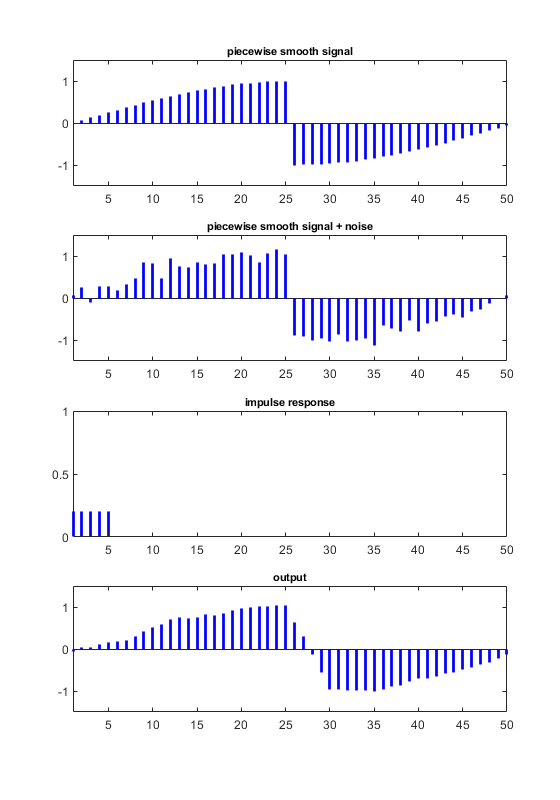

```matlab
%plot -s 560,800

N = 50;
n = 0:N-1;
s = sin(pi/N*n) .* [ones(1,N/2), -ones(1,N/2)];

subplot(4,1,1)
stem(s,'b','Marker','none','LineWidth',2);
axis([1 N -1.5 1.5])
title('piecewise smooth signal','fontsize',8)

% add noise to the signal
x = s + 0.1*randn(1,N);

subplot(4,1,2)
stem(x,'b','Marker','none','LineWidth',2);
axis([1 N -1.5 1.5])
title('piecewise smooth signal + noise','fontsize',8)

% construct moving average filter impulse response of length M
M = 5;
h = ones(1,M)/M;

subplot(4,1,3)
stem(h,'b','Marker','none','LineWidth',2);
axis([1 N 0 1])
title('impulse response','fontsize',8)

% convolve noisy signal with impulse response
y = cconv(x,h,N);

subplot(4,1,4)
stem(y,'b','Marker','none','LineWidth',2);
axis([1 N -1.5 1.5])
title('output','fontsize',8)
```

## 4.2. Edge Detection

Edge detection is the process of identifying abrupt transitions or discontinuities in a signal. These transitions often correspond to important structural features, such as object boundaries in images or sudden changes in temporal signals.

A common approach is to use a high-pass filter that responds strongly to rapid changes while suppressing smooth or constant regions.

Consider the following impulse response:

$$ h[n] = \frac{1}{4} \, [-1, -1, 1, 1] $$

This highlights regions where the signal changes from low to high or vice versa. Specifically:

- Flat or slowly varying regions yield near-zero output
- Sharp transitions produce strong positive or negative responses, depending on the direction of change

This filter effectively computes a local contrast across four adjacent samples:

This makes it sensitive to edges centered between the second and third elements of the window.

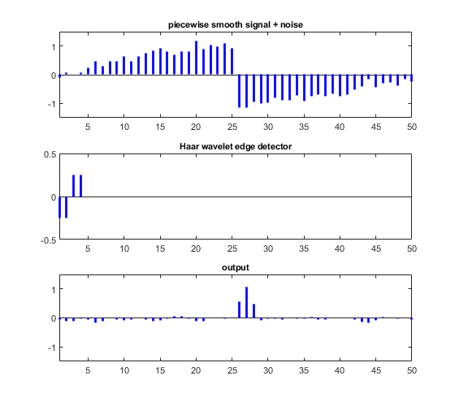

```matlab
%plot -s 560,500

N = 50;
n = 0:N-1;
s = sin(pi/N*n) .* [ones(1,N/2), -ones(1,N/2)];

% add noise to the signal
x = s + 0.1*randn(1,N);

subplot(311)
stem(x,'b','Marker','none','LineWidth',2);
axis([1 N -1.5 1.5])
title('piecewise smooth signal + noise','fontsize',8)

% haar wavelet edge detector
h = (1/4)*[-ones(1,2), ones(1,2)];

subplot(312)
stem(h,'b','Marker','none','LineWidth',2);
axis([1 N -0.5 0.5])
title('Haar wavelet edge detector','fontsize',8)

% % convolve noisy signal with impulse response
y = cconv(x,h,N);

subplot(313)
stem(y,'b','Marker','none','LineWidth',2);
axis([1 N -1.5 1.5])
title('output','fontsize',8)
```

## 4.3. Convolution on Audio

(Source: "ThinkDSP" by Prof. Allen Downey at Olin College)

We consider two real-world audio signals for this example:

- Download [wave file 1](https://drive.google.com/file/d/1rL0tN3WTkC4MBtdheoAWyBr6e_IWEux4/view?usp=sharing)
- Download [wave file 2](https://drive.google.com/file/d/19CFQjziN_BENA26Zw5jkPE8u7Za2C5FO/view?usp=sharing)

**Simulating Reverberation**

To simulate how a violin might sound in a reverberant environment, we apply convolution between the violin signal and a gunshot waveform. The gunshot serves as a synthetic impulse response that characterizes the acoustic behavior of the simulated environment.

The convolution is expressed as:

$$ y[n] = x[n] * h[n] $$

where:

- $x[n]$ is the input signal (violin),
- $h[n]$ is the impulse response (gunshot),
- $y[n]$ is the output signal with simulated reverberation.

This example highlights a key application of convolution in digital audio: the ability to model and synthesize realistic acoustic effects by applying an impulse response to a clean signal. Such techniques are widely used in virtual acoustics, sound design, and music production.

```matlab
[x, Fs] = audioread([pwd,'\data_files\violin_origional.wav']);

x = x/max(x);  % normalize
sound(x, Fs);  % play a wave file with sampling rate Fs
```

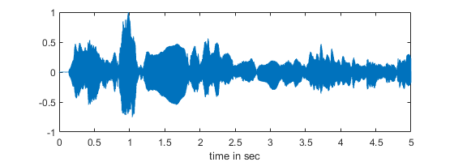

```matlab
%plot -s 560,200

% plot wave file
xn = (1:length(x))/Fs;
plot(xn,x), xlabel('time in sec')
```

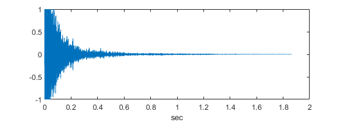

```matlab
% impulse response in a closed room (by gunshot)

[h, Fs] = audioread([pwd,'\data_files\gunshot.wav']);
h = h(:,1); % stereo to mono

sound(h, Fs);
plot((1:length(h))/Fs, h), xlabel('sec')
```

```matlab
% image how the music played in a closed room sounds like

y = cconv(x,h);
y = y/max(y);

sound(y, Fs);
```

```matlab
%%javascript
$.getScript('https://kmahelona.github.io/ipython_notebook_goodies/ipython_notebook_toc.js')
```